# Variation of power plants capacity amoung fuel kind and time

## by Aiman Azzi

## Investigation Overview

In this investigation, I wanted to see the variation of capacity_mw variable amoung other features: **primary_fuel** for categorisation, and **commissioning_year** for time growth.

## Dataset Overview

The data consisted of capacity greater than 1 **MW** and other features of nearly 35000 power plants across the world. The features included many features like: power generation, primary fuel used and years of operation. It had 324 unvalid rows, many outliers and unnecessary columns that were dropped for this analyses.

## Distribution of Capacity Values.

Using logarithmic scale, the distribution of capacity have a multimodal shape. The capacity in th dataset is taking a wide range of values, starting from $1 MW$ to $2000 MW$.

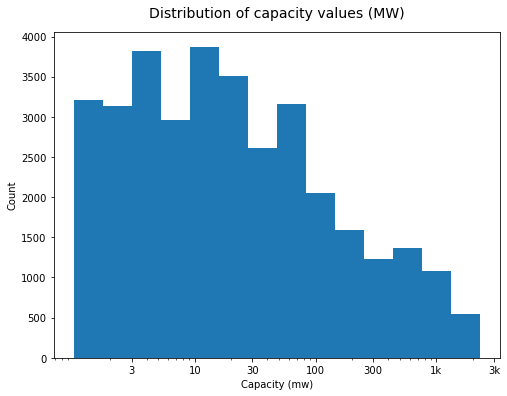

## Distribution of Primary Fuel.

There are many fuel kinds in this data. The distribution of fuel categories shows the number of plants for each categorie. The Most used three fuels are renewable energies: **Solar**, **Hydro** and **Wind**.

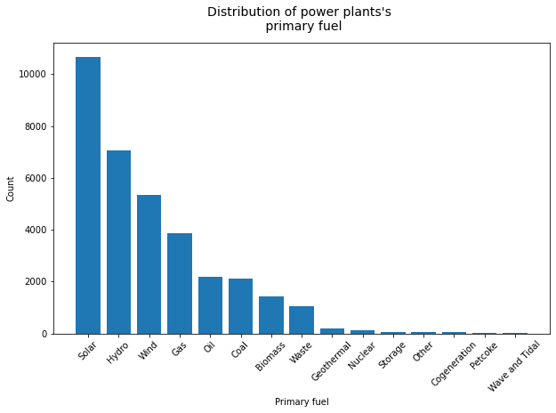

## Capacity amoung Years.

The growth of capacity amoung years is changing from period to another, on general there is an increasement until around 1940. Then close to 1980 it start rising again until it reaches it's highest value (More than $400 MW$) and begins to drop, it increases again from the 90's to after 2000's, but the last 20 years it is falling down.

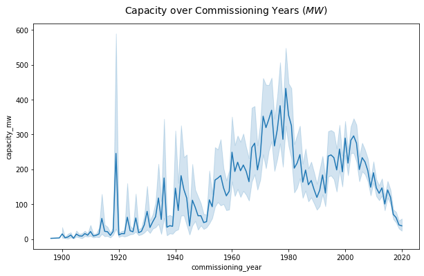

## Capacity vs. Primary Fuel

Whether the fuel type has a high or low frequency, in this dataset it's not always related to the capacity. Against to the distribution of primary fuel, Nuclear fuel has the highest capacity average, followed by Coal and Gas. While Solar and Wind have low capacity even their huge frequency in plants usage.

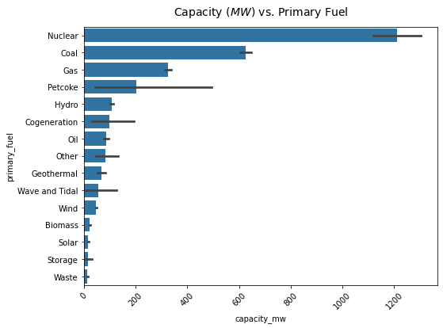

## Capacity vs. Years for each Fuel kind.

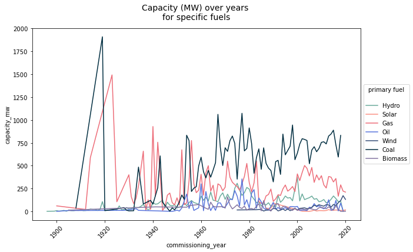